# Graphing in R: 101

## 2. Add data using `mapping =` argument/parameter.

To `mapping`, we are required to supply the variables which we wish to map using the `aes` function. The idea behind `aes` is that we may want to map many aspects of our data to different aesthetics elements of the layer we’re plotting (demonstrated below). Nevertheless they are all still “aesthetic mappings”, and so we set `mapping = aes()`. Additionally, if we are to supply variables, we must have some data (unles we’re going) to use those “x” and “y” variables that we created earlier in this tutorial. But typically, we wish to instruct `ggplot` to graph variable from within a dataframe that we are supplying as a whole to `ggplot`. So below we set the argument `data = diamonds`, and then can set `mapping = aes(x = carat, y = price)`

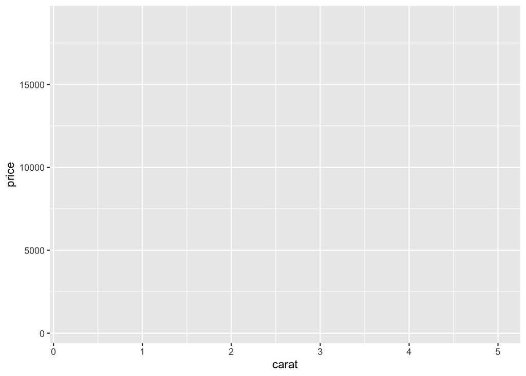

```r
ggplot(data = diamonds, mapping = aes(x = carat, y = price))
```

Interesting. Now this layer has been populated with some information, but what is still missing?

We have mapped our variables to the x and y axes, but we have not assigned them a geometric representation! Even if we put our variables into a coordinate system, we can conceivably generate several different aesthetic representation of them. To visualize the data as a scatterplot, we use `geom_point`.